# TP Clustering

Partie 3 : Classification hiérarchique

4modIA / 2023-2024

L’objectif de ce TP est d’illustrer les notions abordées pour classification hiérarchique. Les librairies R nécessaires pour ce TP :

```r
library(mclust)
library(clusterSim)
library(factoextra)
library(FactoMineR)
library(ggplot2)
library(reshape2)
library(circlize)
library(viridis)
```

# 1 Clustering des données de vin par CAH

On reprend dans ce TP les données `wine` disponibles sur la page moodle du cours. On charge ici les données.

```r
wine<-read.table("wine.txt",header=T)
wine$Qualite = as.factor(wine$Qualite)
wine$Type = factor(wine$Type, labels = c("blanc", "rouge"))
wineinit<-wine
wine[,-c(1,2)]<-scale(wine[,-c(1,2)],center=T,scale=T)
head(wine)
```

```
##      Qualite  Type      AcidVol    AcidCitr     SO2lbr      SO2tot     Densite
## 1352  medium rouge  1.638714588 -1.92626362 -1.2083376 -1.15967786 -0.46497450
## 5493  medium blanc -0.068544417 -1.35617574 -0.7004747 -0.85707581 -0.33499781
## 5153  medium blanc -0.800226847 -0.59605856  0.5409681 -0.02047014  1.32391517
## 5308  medium blanc -0.007570881  0.92417581  1.7824108  1.27893867  1.08790487
## 3866  medium blanc  0.419243870  0.03737243 -0.5311870  0.99413674  0.03783006
## 694   medium rouge  0.785085086  0.03737243 -0.4747578  0.19313131  1.27260858
##           Alcool
## 1352  1.14546909
## 5493 -1.12092616
## 5153 -1.29526426
## 5308 -1.29526426
## 3866  0.09944051
## 694  -0.94658806
```

On fait une ACP pour la visualisation des résultats dans la suite

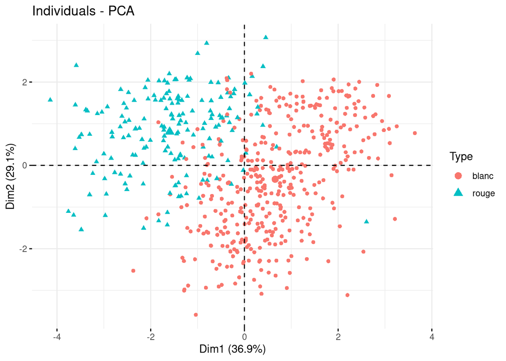

```r
resacp<-PCA(wine,quali.sup=c(1,2), scale.unit = TRUE,graph=FALSE)
fviz_pca_ind(resacp,geom=c("point"),habillage=2)
```

**Question** : A l’aide de la fonction `hclust`, faites une classification hiérarchique des données de vins avec les mesures d’agrégation `single`, `complete` et `average` respectivement. Comparez visuellement les dendrogrammes associés. Commentez.

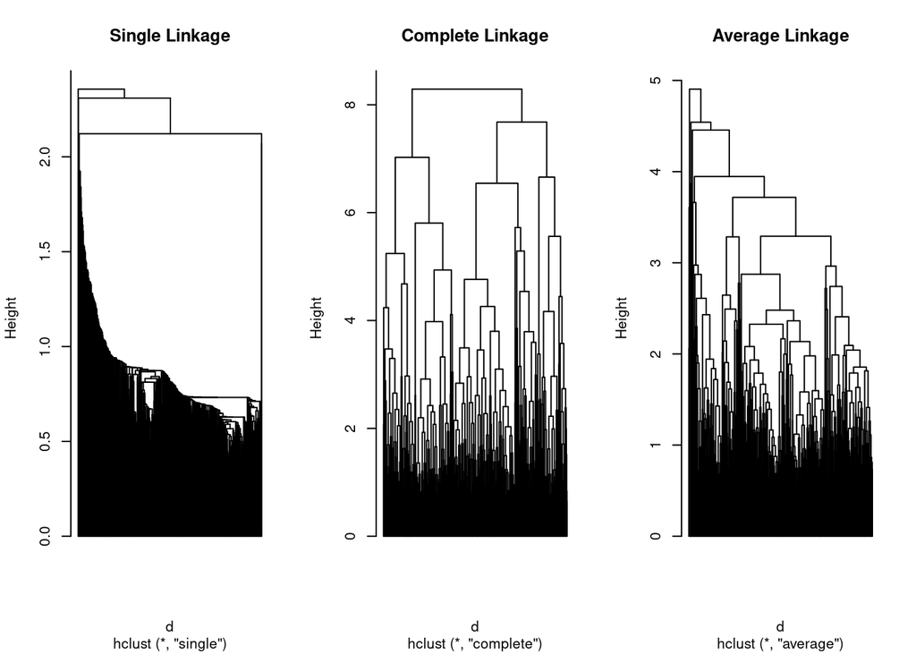

```r
# Clustering Hiérarchique
d = dist(wine[, -c(1, 2)])
hclustsingle <- hclust(d, method = "single")
hclustcomplete <- hclust(d, method = "complete")
hclustaverage <- hclust(d, method = "average")

# Dendrogramme
par(mfrow = c(1, 3))
plot(hclustsingle, hang = -1, labels = FALSE, main = "Single Linkage")
plot(hclustcomplete, hang = -1, labels = FALSE, main = "Complete Linkage")
plot(hclustaverage, hang = -1, labels = FALSE, main = "Average Linkage")
```

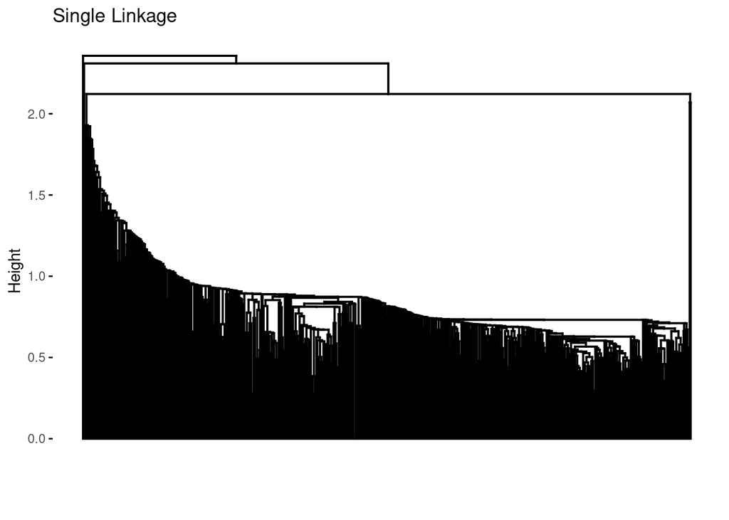

```r
# Visualiser les dendogrammes
fviz_dend(hclustsingle, show_labels = FALSE, main = "Single Linkage")
```

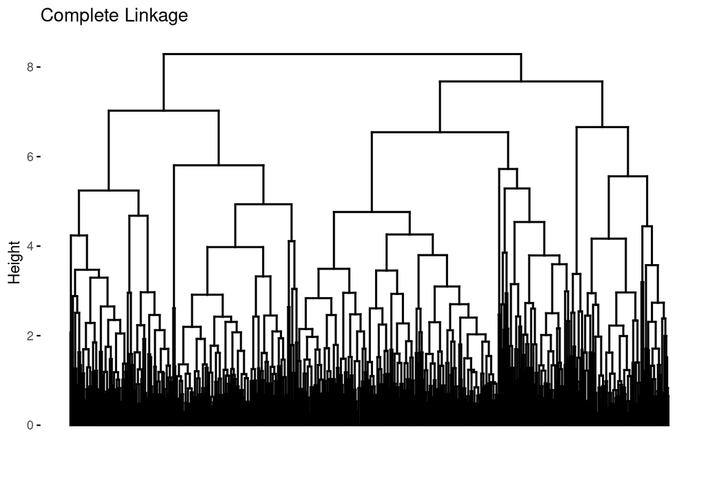

```r
fviz_dend(hclustcomplete, show_labels = FALSE, main = "Complete Linkage")
```

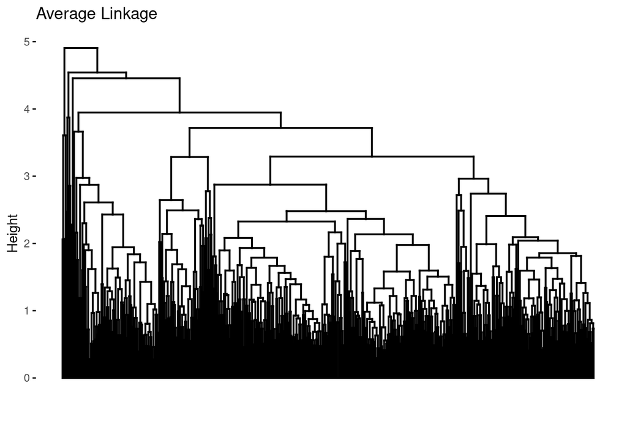

```r
fviz_dend(hclustaverage, show_labels = FALSE, main = "Average Linkage")
```

**Question :** Déduisez du dendrogramme avec la mesure d’agrégation `complete` une classification en 3 classes. Vous pouvez utiliser la fonction `cutree()`. Comparez-la avec les variables *Qualité* et *Type*. Commentez.

```r
# Classification en 3 classes avec la mesure d'agrégation complete
ClassK3 <- cutree(hclustcomplete, k = 3)

# Ajouter les classes à votre jeu de données
wine_with_classes <- cbind(wine, Cluster = ClassK3)

# Afficher la table de contingence entre la classification obtenue et la variable 'Qualite'
table(wine_with_classes$Cluster, wine_with_classes$Qualite)
```

```
##
##     bad good medium
##   1   6   13     80
##   2   9   39    225
##   3   4   58    166
```

```r
# Afficher la table de contingence entre la classification obtenue et la variable 'Type'
table(wine_with_classes$Cluster, wine_with_classes$Type)
```

```
##
##     blanc rouge
##   1    20    79
##   2   178    95
##   3   227     1
```

**Question :** Tracez la distribution des variables quantitatives de `wine` en fonction de la classification en 3 classes de la question précédente. Commentez.

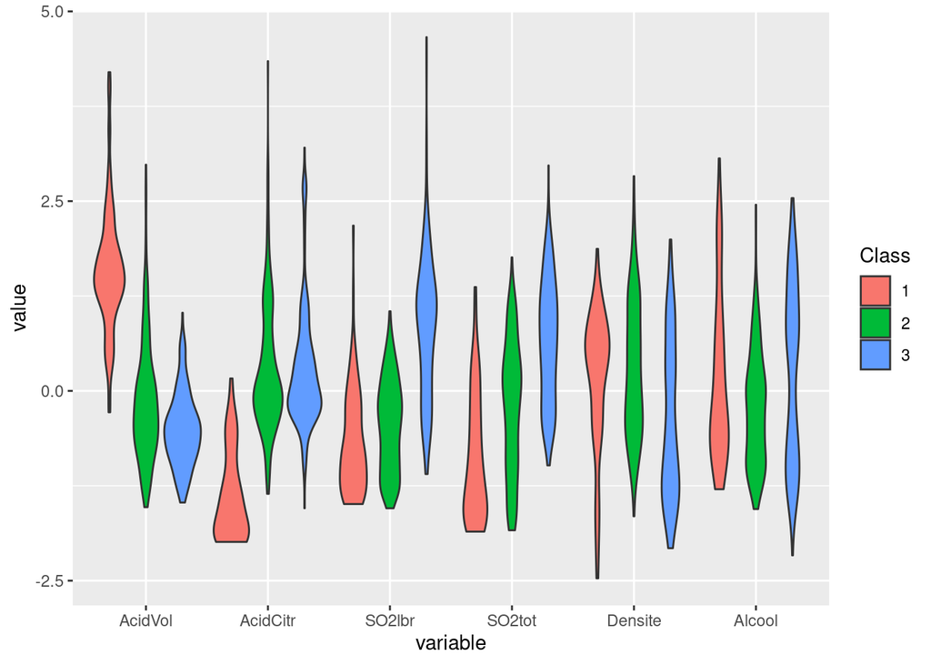

```r
df<-data.frame(wine[,-c(1,2)],Class=as.factor(ClassK3))
df<-melt(df,id="Class")
ggplot(df,aes(x=variable,y=value))+geom_violin(aes(fill=Class))
```

**Question :** Dans cette question et pour les suivantes, on se focalise sur la mesure d’agrégation de Ward. Ajustez une classification hiérarchique avec la mesure de Ward. Que représentent les hauteurs du dendrogramme dans ce cas ?

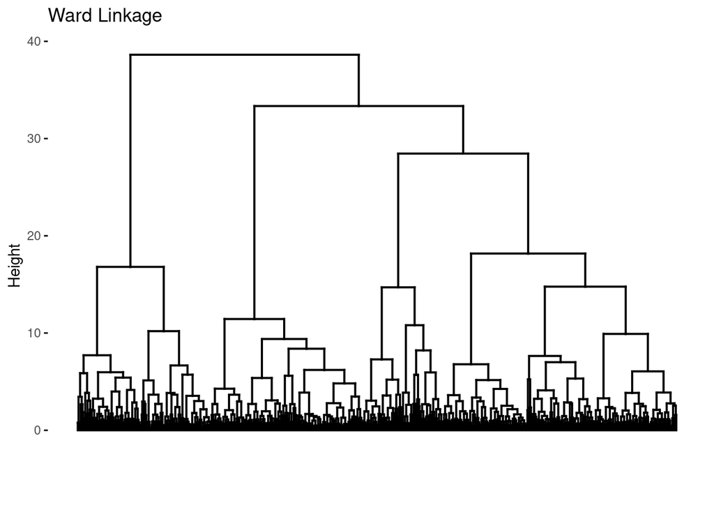

```r
# Classification hiérarchique avec la mesure de Ward
hward <- hclust(d, method = "ward.D2")

# Visualiser le dendrogramme
fviz_dend(hward, show_labels = FALSE, main = "Ward Linkage")
```

**Question :** Déterminez le nombre de classes à retenir avec l’indice de Calinski-Harabasz. Vous pouvez vous aider de la fonction `ìndex.G1()` de la librairie `clusterSim`. Tracez la classification obtenue sur le dendrogramme et sur le premier plan factoriel de l’ACP.

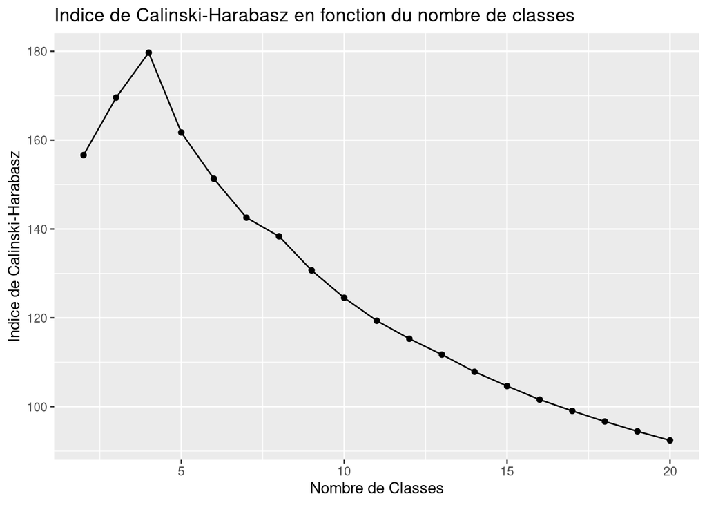

```r
# Calcul de l'indice de Calinski-Harabasz pour différents nombres de classes
CH <- NULL
Kmax <- 20
for (k in 2:Kmax) {
  CH <- c(CH, index.G1(wine[, -c(1, 2)], cutree(hward, k)))
}

# Création d'un data frame pour la visualisation
daux <- data.frame(NbClust = 2:Kmax, CH = CH)

# Tracer la courbe de l'indice de Calinski-Harabasz
ggplot(daux, aes(x = NbClust, y = CH)) +
  geom_line() +
  geom_point() +
  labs(title = "Indice de Calinski-Harabasz en fonction du nombre de classes", x = "Nombre de Classes", y = "Indice de Calinski-Harabasz")
```

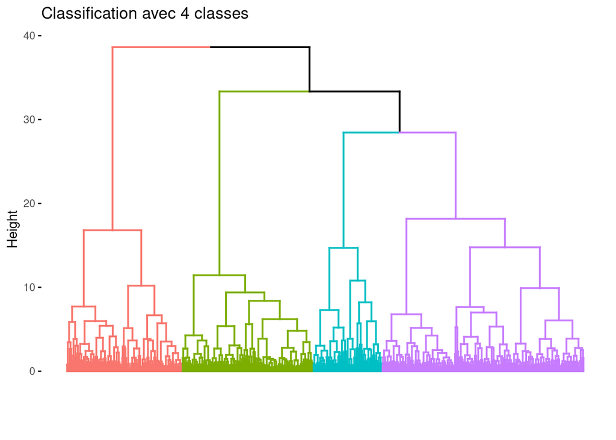

```r
# Nombre de classes optimal selon l'indice de Calinski-Harabasz
optimal_clusters <- daux$NbClust[which.max(daux$CH)]

# Classification avec le nombre optimal de classes
ClustCH <- cutree(hward, optimal_clusters)

# Afficher la classification sur le dendrogramme
fviz_dend(hward, show_labels = FALSE, k = optimal_clusters, main = paste("Classification avec", optimal_clusters, "classes"))
```

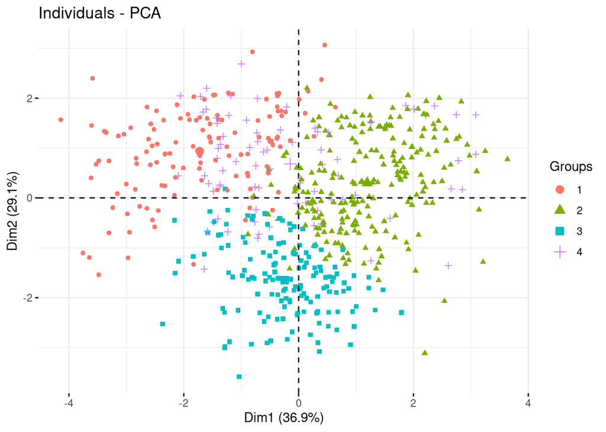

```r
# Afficher la classification sur le premier plan factoriel de l'ACP
fviz_pca_ind(resacp, geom = "point", habillage = as.factor(ClustCH))
```

```r
daux1=data.frame(NbClust=1:Kmax, intra=rev(hward$height[tail(1:nrow(wine), Kmax)-1]))
ggplot(daux1, aes(x=NbClust, y=intra)) + geom_line() + geom_point()
```

[output not shown]

**Question :** Déterminez le nombre de classes à retenir avec le critère Silhouette. Vous pouvez vous aider de la fonction `ìndex.S()` de la librairie `clusterSim`. Comparez avec la classification de la question précédente.

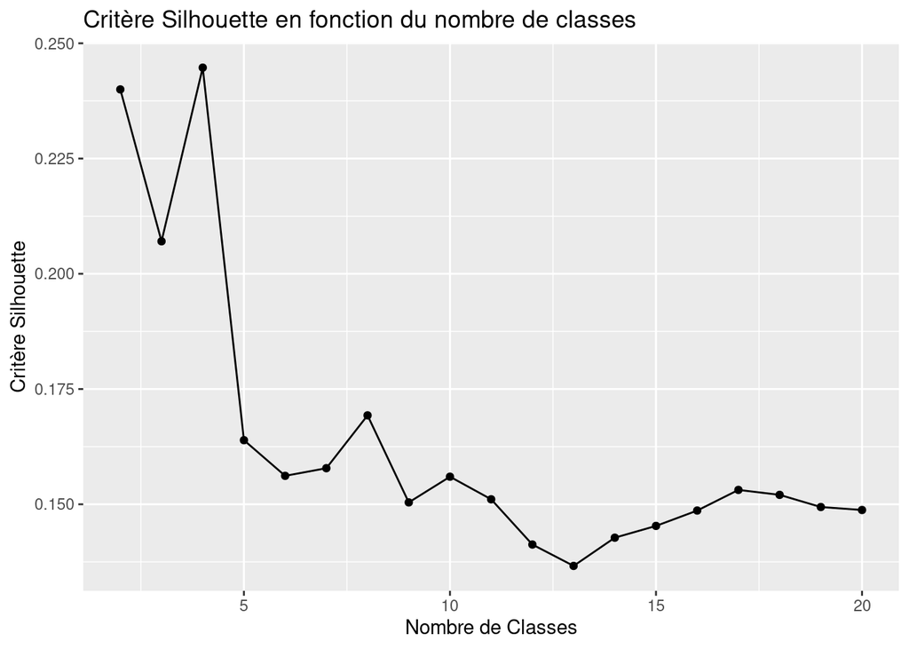

```r
# Calcul du critère Silhouette pour différents nombres de classes
silhouette <- NULL
for (k in 2:Kmax) {
  silhouette <- c(silhouette, index.S(d, cutree(hward, k)))
}

# Création d'un data frame pour la visualisation
daux_silhouette <- data.frame(NbClust = 2:Kmax, Silhouette = silhouette)

# Tracer la courbe du critère Silhouette
ggplot(daux_silhouette, aes(x = NbClust, y = Silhouette)) +
  geom_line() +
  geom_point() +
  labs(title = "Critère Silhouette en fonction du nombre de classes", x = "Nombre de Classes", y = "Critère Silhouette")
```

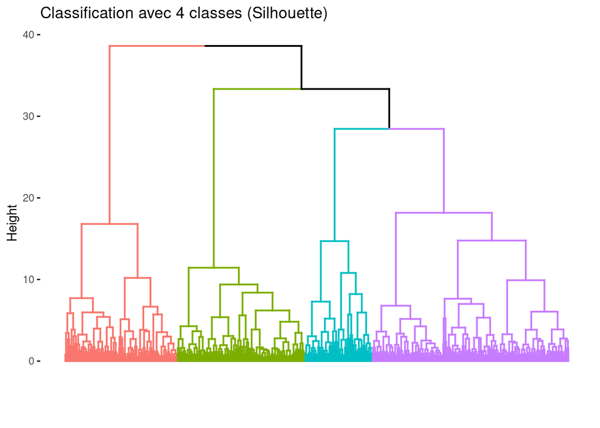

```r
# Nombre de classes optimal selon le critère Silhouette
optimal_clusters_silhouette <- daux_silhouette$NbClust[which.max(daux_silhouette$Silhouette)]

# Classification avec le nombre optimal de classes selon le critère Silhouette
ClustSilhouette <- cutree(hward, optimal_clusters_silhouette)

# Afficher la classification du critère Silhouette sur le dendrogramme
fviz_dend(hward, show_labels = FALSE, k = optimal_clusters_silhouette, main = paste("Classification avec", optimal_clusters_silhouette, "classes (Silhouette)"))
```

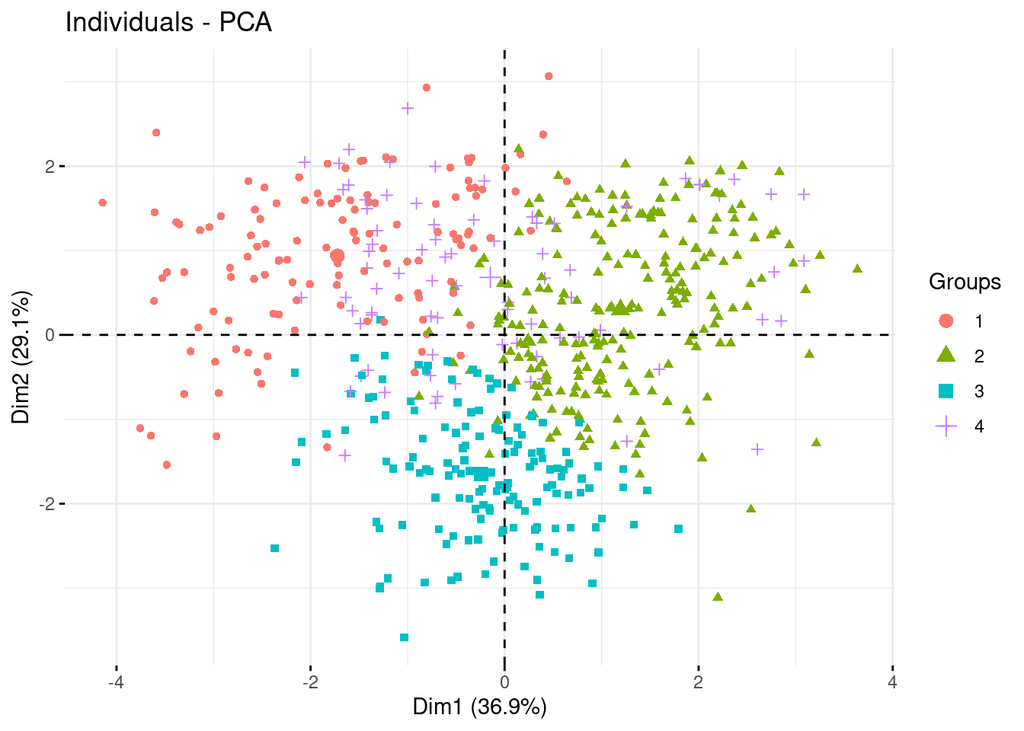

```r
# Afficher la classification du critère Silhouette sur le premier plan factoriel de l'ACP
fviz_pca_ind(resacp, geom = "point", habillage = as.factor(ClustSilhouette))
```

```r
# Comparaison avec la classification précédente
comparison_table <- data.frame(ClustCH, ClustSilhouette)
colnames(comparison_table) <- c("Classe_CH", "Classe_Silhouette")

# Afficher la table de comparaison
print(comparison_table)
```

```
##      Classe_CH Classe_Silhouette
## 1352         1                 1
## 5493         1                 1
## 5153         2                 2
## 5308         2                 2
## 3866         2                 2
## 694          1                 1
## 5085         2                 2
## 2280         2                 2
## 5231         3                 3
## 4388         2                 2
## 4172         2                 2
## 4763         3                 3
## 4001         4                 4
## 3244         2                 2
```

[output cut: 586 more lines]

```
##   cluster size ave.sil.width
## 1       1  134          0.25
## 2       2  234          0.22
## 3       3  152          0.35
## 4       4   80          0.11
```

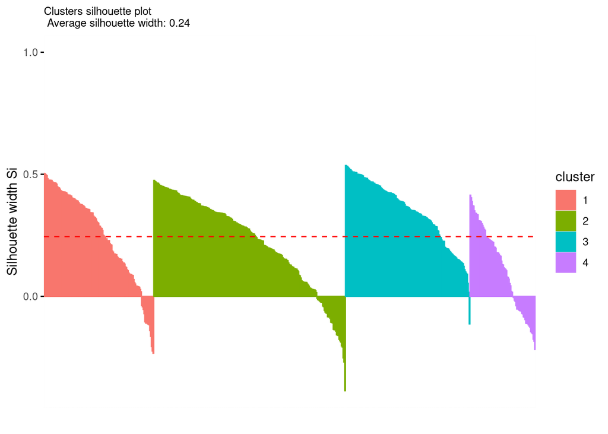

```r
aux <- silhouette(ClustSilhouette, d)
fviz_silhouette(aux)+theme(plot.title = element_text(size = 9))
```

**Question :** Comparez la classification obtenue avec la méthode des Kmeans dans le TP 1 et celle obtenue à la question précédente.

```r
# Classification avec la méthode des K-means du TP1
set.seed(123)  # Pour assurer la reproductibilité
kmeans_clusters <- kmeans(wine[, -c(1, 2)], centers = optimal_clusters_silhouette)

# Comparaison des classifications
comparison_table_kmeans <- data.frame(ClustKmeans = kmeans_clusters$cluster, ClustWard = ClustSilhouette)

# Afficher la table de comparaison
print(comparison_table_kmeans)

# Table de contingence entre les classifications des deux méthodes
table_comparison <- table(ClustKmeans = kmeans_clusters$cluster, ClustWard = ClustSilhouette)

# Afficher la table de contingence
print(table_comparison)
```

[output not shown]

# 2 Clustering des données Zoo par CAH

## 2.1 Lecture des données et fonctions auxiliaires

On reprend dans cette partie le jeu de données zoo ainsi que les fonctions auxiliaires comme dans le TP1. On refait une analyse en composantes multiples pour la suite.

```r
zoo<-read.table("zoo-dataTP.txt",header=T,stringsAsFactors = TRUE)
for (j in 1:ncol(zoo))
  zoo[,j]<-as.factor(zoo[,j])
summary(zoo)
library("FactoMineR")
library("factoextra")
res.mca<- MCA(zoo,ncp = 5, graph = FALSE)

fviz_screeplot(res.mca)
plot(res.mca, invisible = c("quali.sup", "ind"), cex=1, col.var = "darkblue", cex.main=2, col.main= "darkblue")

fviz_mca_ind(res.mca)
```

[output not shown]

Pour la suite du TP, on pourra utiliser les fonctions auxiliaires suivantes. La fonction `barplotClus()` permet de tracer la répartition des modalités de variables qualitatives pour chaque classe d’un clustering donné.

```r
# J indice des variables
# Data = jeu de données
# clust = clustering étudié
# output : graphe par variable dans J donnant la répartition des modalités de J par classe de clust

barplotClus <- function(clust, Data, J) {
    aux.long.p <- heatm(clust, Data, J)$freq
    # ux<-unique(aux.long.p$variable)
    for (j in J) {
        p <- ggplot(aux.long.p[which(aux.long.p$variable == colnames(Data)[j]), ],
            aes(x = clust, y = perc, fill = value)) + geom_bar(stat = "identity")+
            labs(fill = colnames(Data)[j])
        print(p)
    }
}

heatm <- function(clust, Data, J) {
    library(dplyr)
    Dataaux <- data.frame(id.s = c(1:nrow(Data)), Data)
    aux <- cbind(Dataaux, clust)
    aux.long <- melt(data.frame(lapply(aux, as.character)), stringsAsFactors = FALSE,
        id = c("id.s", "clust"), factorsAsStrings = T)
    # Effectifs
    aux.long.q <- aux.long %>%
        group_by(clust, variable, value) %>%
        mutate(count = n_distinct(id.s)) %>%
        distinct(clust, variable, value, count)
    # avec fréquences
    aux.long.p <- aux.long.q %>%
        group_by(clust, variable) %>%
        mutate(perc = count/sum(count)) %>%
        arrange(clust)

    Lev <- NULL
    for (j in 1:ncol(Data)) Lev <- c(Lev, levels(Data[, j]))

    Jaux <- NULL
    for (j in 1:length(J)) {
        Jaux <- c(Jaux, which(aux.long.p$variable == colnames(Data)[J[j]]))
    }

    gaux <- ggplot(aux.long.p[Jaux, ], aes(x = clust, y = value)) + geom_tile(aes(fill = perc)) +
        scale_fill_gradient2(low = "white", mid = "blue", high = "red") + theme_minimal()

    return(list(gaux = gaux, eff = aux.long.q, freq = aux.long.p))
}
```

## 2.2 CAH directe sur variables qualitatives

**Question :** Quelle classification par CAH pouvez-vous mettre en place pour traiter des données qualitatives ? Mettez en application votre proposition avec R et étudiez la classification retenue. Vous pourrez vous aider des fonctions `daisy()` de la librairie `cluster`, de la fonction `hclust()`, …

```r
# Calcul de la matrice de dissimilarité
dissimilarity_matrix <- daisy(zoo, metric = "gower")

# Classification ascendante hiérarchique
hclust_quali <- hclust(dissimilarity_matrix, method = "ward.D2")

# Dendrogramme
plot(hclust_quali, hang = -1, labels = FALSE, main = "CAH - Variables Qualitatives")

# Visualiser le dendrogramme
fviz_dend(hclust_quali, show_labels = FALSE, main = "CAH - Variables Qualitatives")
```

[output not shown]

## 2.3 CAH sur les coordonnées de MCA

**Question :** Mettez en place une classification des animaux à partir des coordonnées de l’analyse en composantes multiples. Comparez avec la classification obtenue dans la section précédente.

```r
# Classification ascendante hiérarchique sur les coordonnées de MCA
hclust_mca <- hclust(res.mca$var$coord, method = "ward.D2")

# Dendrogramme
plot(hclust_mca, hang = -1, labels = FALSE, main = "CAH - Coordonnées de MCA")

# Visualiser le dendrogramme
fviz_dend(hclust_mca, show_labels = FALSE, main = "CAH - Coordonnées de MCA")
```

[output not shown]